# Taller # 1 - Aprendizaje Estadístico - Solución

Maestría en Inteligencia de Negocios - UEC

Andrés Cruz Pérez

Nov-2021

### ¿Qué vamos a hacer?

Los temas que hemos visto en la primera clase, ademas de las consultas pertinentes, nos deben permitir realizar un análisis primario de un conjunto de datos. Para este ejercicio podemos hacer uso de la base de datos **saber** que se puede encontrar en [este repositorio de github](https://github.com/nebulae-co/saber). El conjunto de datos contiene los registros correspondientes a los resultados de la prueba Saber 11 de un periodo específico. El diccionario de variables de los conjuntos de datos se encuentra [aqui](http://18.213.195.57:8081/documents/20143/517898/Diccionario%20saber%2011%202006%201%20a%202012%202.pdf).

Realizaremos una serie de análisis a este conjunto de datos usando las herramientas que hemos aprendido.

### Carga de datos

Con el siguiente código descargue e instale el paquete saber, que contiene conjuntos de datos. Recuerde que las instalaciones de este tipo se realizan en la consola una sola vez.

```r
## En la consola!!
# install.packages("devtools")
devtools::install_github("nebulae-co/saber")
```

Lo anterior puede demorar un poco, luego de eso instale y cargue las librerías:

```r
library("tidyverse")
library("esquisse")
library("knitr")
library("magrittr")
library("saber")
```

y los datos

```r
data("SB11_20061")
datos = SB11_20061
library(tidyverse)
# View(datos)
```

### Características generales

La exploración del conjunto de datos se puede realizar de diversas formas, los scrips estudiados en clase nos pueden ayudar. Respondamos las siguientes preguntas:

- P1: ¿Cuántas columnas tiene la base de datos?

```r
attach(SB11_20061)
P1=ncol(SB11_20061)
print(P1)
```

```
## [1] 86
```

- P2: ¿Cuántas de estas son categóricas?

```r
P2=sum(map_lgl(SB11_20061,is.character))
print(P2)
```

```
## [1] 42
```

- P3: ¿Cuántas de estas son numéricas?

```r
P3=sum(map_lgl(SB11_20061,is.numeric))
print(P3)
```

```
## [1] 44
```

… una forma alternativa

```r
table(sapply(datos, class))
```

```
##
## character   integer   numeric
##        42        34        10
```

- P4: ¿Cuántos registros tiene la base de datos?

```r
P4=nrow(SB11_20061)
print(P4)
```

```
## [1] 61069
```

### Particularidades

Podemos también responder algunas preguntas muy fáciles sobre la prueba Saber 11.

- P5: ¿Cuál es el departamento (`ESTU_RESIDE_DEPT_PRESENTACION`) en el que reside el estudiante que tuvo el puntaje en física (`FISICA_PUNT`) más alto?

```r
p5=datos[FISICA_PUNT==max(FISICA_PUNT),"ESTU_RESIDE_DEPT_PRESENTACION"]
table(p5)
```

```
## p5
## BOGOTÃ\201   VALLE
##       1       1
```

… la siguiente es otra forma de hacerlo, pero únicamente nos muestra el primero de la lista con la característica de interés o el que tenga la frecuencia más alta.

```r
P5=extract(ESTU_RESIDE_DEPT_PRESENTACION,
        which.max(FISICA_PUNT))
print(P5)
```

```
## [1] "BOGOTÃ\201"
```

- P6: ¿Cuál es el municipio (`ESTU_RESIDE_MPIO_PRESENTACION`) en el que reside el estudiante que tuvo el puntaje en física (`FISICA_PUNT`) más bajo?

```r
p6 = datos[FISICA_PUNT==min(FISICA_PUNT),"ESTU_RESIDE_MPIO_PRESENTACION"]
table(p6)
```

```
## p6
##     CALI  FLORIDA  IPIALES    PASTO     TORO TRUJILLO   TUMACO    VIJES
##        5        1        1        2        1        1        1        1
##    YOPAL
##        1
```

… la siguiente es otra forma de hacerlo, pero únicamente nos muestra el primero de la lista con la característica de interés o el que tenga la frecuencia más alta.

```r
P6=extract(ESTU_RESIDE_MPIO_PRESENTACION,
            which.min(FISICA_PUNT))
print(P6)
```

```
## [1] "CALI"
```

- P7: ¿Cuál es el departamento (`ESTU_RESIDE_DEPT_PRESENTACION`) en el que reside el estudiante que tuvo el puntaje en filosofía (`FILOSOFIA_PUNT`) más alto?

```r
p7 = datos[FILOSOFIA_PUNT==max(FILOSOFIA_PUNT),"ESTU_RESIDE_DEPT_PRESENTACION"]
table(p7)
```

```
## p7
## BOGOTÃ\201
##       1
```

… la siguiente es otra forma de hacerlo, pero únicamente nos muestra el primero de la lista con la característica de interés o el que tenga la frecuencia más alta.

```r
P7=extract(ESTU_RESIDE_DEPT_PRESENTACION,
            which.max(FILOSOFIA_PUNT))
print(P7)
```

```
## [1] "BOGOTÃ\201"
```

- P8: ¿Cuál es el municipio (`ESTU_RESIDE_MPIO_PRESENTACION`) en el que reside el estudiante que tuvo el puntaje en filosofía (`FILOSOFIA_PUNT`) más bajo?

```r
p8 = datos[FILOSOFIA_PUNT==min(FILOSOFIA_PUNT),"ESTU_RESIDE_MPIO_PRESENTACION"]
table(p8)
```

```
## p8
##       ALBAN (SAN JOSE)           BUENAVENTURA                   CALI
##                      1                      5                     19
##             EL CERRITO                GUACARI                JAMUNDI
##                      2                      1                      2
##                PALMIRA                POPAYAN                PRADERA
##                      1                      1                      1
##  SANTAFÃ‰ DE ANTIOQUIA SANTANDER DE QUILICHAO                   TORO
##                      1                      1                      2
##             YACUANQUER
##                      1
```

… la siguiente es otra forma de hacerlo, pero únicamente nos muestra el primero de la lista con la característica de interés o el que tenga la frecuencia más alta.

```r
P8=extract(ESTU_RESIDE_MPIO_PRESENTACION,
            which.min(FILOSOFIA_PUNT))
print(P8)
```

```
## [1] "CALI"
```

## Univariados

### Estadísticos univariados

Para comenzar podemos calcular algunos descriptivos univariados.

- P9: ¿Cuál es el promedio del puntaje de matemáticas (`MATEMATICAS_PUNT`)?

```r
P9=round(mean(MATEMATICAS_PUNT, na.rm = TRUE),2)
print(P9)
```

```
## [1] 50.77
```

- P10: ¿Cuál es el la desviación estándar del puntaje de matemáticas (`MATEMATICAS_PUNT`)?

```r
P10=round(sd(MATEMATICAS_PUNT, na.rm = TRUE),2)
print(P10)
```

```
## [1] 9.64
```

- P11: ¿Qué porcentaje de los estudiantes tiene acceso a un computador (`ECON_SN_COMPUTADOR`)?

```r
P11=round(mean(ECON_SN_COMPUTADOR!= 0, na.rm = TRUE)*100,2)
print(P11)
```

```
## [1] 78.94
```

- P12: ¿Qué porcentaje de los estudiantes trabaja (`ESTU_TRABAJA`)?

```r
P12=round(mean(ESTU_TRABAJA != 0, na.rm = TRUE)*100,2)
print(P12)
```

```
## [1] 44.73
```

- P13: ¿Qué porcentaje de los estudiantes hay en colegios oficiales (`COLE_NATURALEZA`)?

```r
P13=round(mean(COLE_NATURALEZA== "O", na.rm = TRUE)*100,2)
print(P13)
```

```
## [1] 59.13
```

- P14: ¿A partir de qué valor de edad comienza el 10% mayor? (`ESTU_EDAD`)

```r
P14=round(quantile(ESTU_EDAD,probs = 0.9, na.rm = TRUE),2)
print(P14)
```

```
## 90%
##  19
```

- P15: ¿Hasta qué valor de edad llega el 15% menor? (`ESTU_EDAD`)

```r
P15=round(quantile(ESTU_EDAD,probs = 0.15, na.rm = TRUE),2)
print(P15)
```

```
## 15%
##  16
```

- P16: ¿Cuáles son los 5 municipios con más estudiantes? (`ESTU_RESIDE_MPIO_PRESENTACION`)

```r
t16=sort(x=table(factor(ESTU_RESIDE_MPIO_PRESENTACION)),decreasing = TRUE, na.rm=TRUE)
t16[1:5]
```

```
##
##         CALI        PASTO BOGOTÃ\201 D.C.      PALMIRA BUENAVENTURA
##        19545         4991         4421         2855         2263
```

… otra alternativa de código

```r
P16 = SB11_20061 %>% count(ESTU_RESIDE_MPIO_PRESENTACION) %>% arrange(desc(n)) %>% head(5) %$% paste(ESTU_RESIDE_MPIO_PRESENTACION, collapse = ", ")
print(P16)
```

```
## [1] "CALI, PASTO, BOGOTÃ\201 D.C., PALMIRA, BUENAVENTURA"
```

### Graficos univariados

Ahora vamos a incursionar en el terreno de los gráficos. Dibujemos las siguientes figuras.

- P17: Histograma del puntaje de lenguaje (`LENGUAJE_PUNT`).

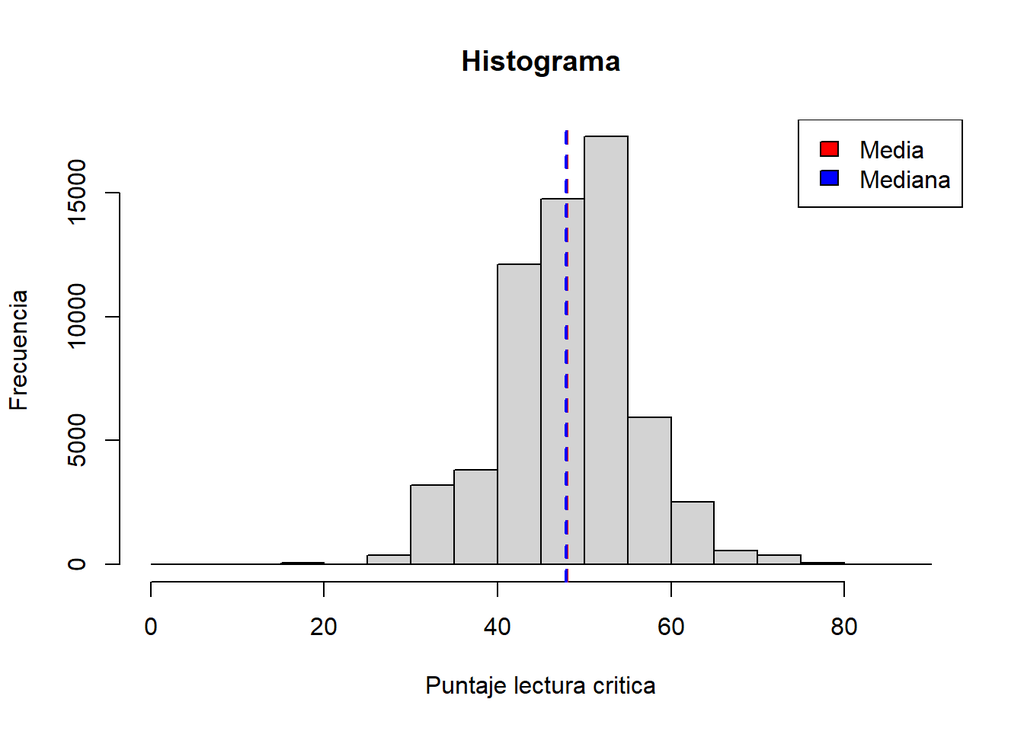

```r
hist(x = LENGUAJE_PUNT, freq = TRUE,
     xlab = "Puntaje lectura critica", ylab = "Frecuencia",
     main = "Histograma", col ="lightgray", border = "black")
abline(v = mean(LENGUAJE_PUNT),   col = "red",  lty = 2, lwd = 2)
abline(v = median(LENGUAJE_PUNT), col = "blue", lty = 2, lwd = 2)
legend("topright", legend = c("Media","Mediana"), fill = c("red","blue"))
```

… otra alternativa de código

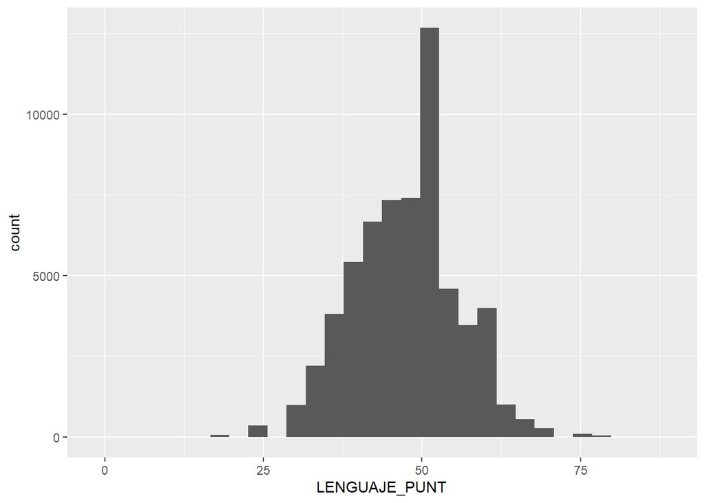

```r
ggplot(SB11_20061) + aes(x = LENGUAJE_PUNT) + geom_histogram()
```

- P18: Gráfico de barras del conteo del estrato (`ESTU_ESTRATO`).

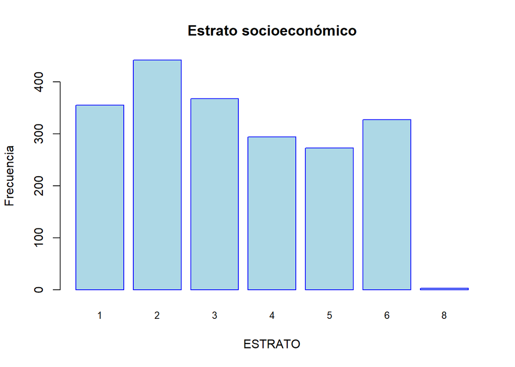

```r
barplot(height = table(ESTU_ESTRATO), col="lightblue", border = "blue",
        xlab = "ESTRATO", ylab = "Frecuencia", main = "Estrato socioeconómico",
        cex.names = 0.8)
```

… otra alternativa de código

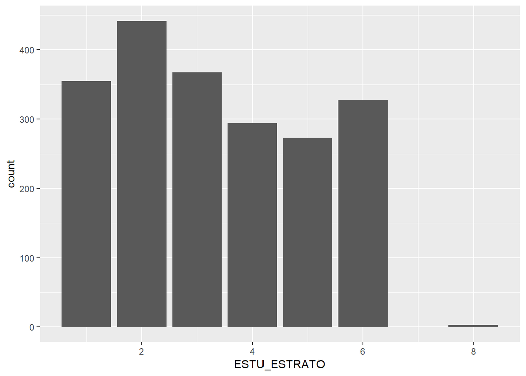

```r
ggplot(SB11_20061) + aes(x = ESTU_ESTRATO) + geom_bar()
```

- P19: Gráfico de caja de la edad (`ESTU_EDAD`).

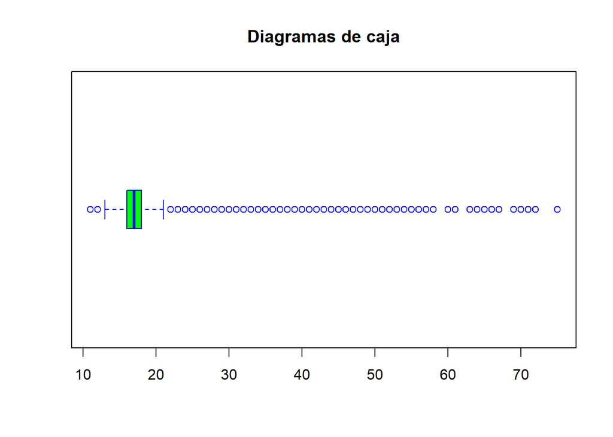

```r
boxplot(ESTU_EDAD, col = "Green", names = c("Edad"),
        main = "Diagramas de caja", horizontal = TRUE,
        border = "blue", boxwex = 0.3)
```

… otra alternativa de código

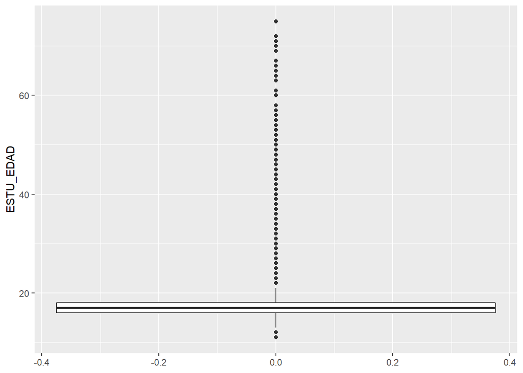

```r
ggplot(SB11_20061) + aes(y = ESTU_EDAD) + geom_boxplot()
```

## Correlaciones

A nivel bivariado podemos indagar las relaciones entre las variables.

- P20: ¿Qué nos dice la matriz de correlaciones de los puntajes (`LENGUAJE_PUNT`, `MATEMATICAS_PUNT`, `CIENCIAS_SOCIALES_PUNT`, `FILOSOFIA_PUNT`, `BIOLOGIA_PUNT`, `QUIMICA_PUNT`, `FISICA_PUNT`)?

```r
M_Cor = data.frame(LENGUAJE_PUNT, MATEMATICAS_PUNT, CIENCIAS_SOCIALES_PUNT, FILOSOFIA_PUNT, BIOLOGIA_PUNT, QUIMICA_PUNT, FISICA_PUNT)
M_Cor = M_Cor[complete.cases(M_Cor),]
colnames(M_Cor) = c("Lenguaje", "Matemáticas", "Sociales", "Filosofia", "Biología", "Quimica", "Fisica")
kable(round(cor(M_Cor),2))
```

|  | Lenguaje | Matemáticas | Sociales | Filosofia | Biología | Quimica | Fisica |
| --- | --- | --- | --- | --- | --- | --- | --- |
| Lenguaje | 1.00 | 0.45 | 0.51 | 0.46 | 0.54 | 0.41 | 0.31 |
| Matemáticas | 0.45 | 1.00 | 0.44 | 0.37 | 0.49 | 0.43 | 0.33 |
| Sociales | 0.51 | 0.44 | 1.00 | 0.48 | 0.55 | 0.42 | 0.31 |
| Filosofia | 0.46 | 0.37 | 0.48 | 1.00 | 0.49 | 0.37 | 0.26 |
| Biología | 0.54 | 0.49 | 0.55 | 0.49 | 1.00 | 0.49 | 0.36 |
| Quimica | 0.41 | 0.43 | 0.42 | 0.37 | 0.49 | 1.00 | 0.32 |
| Fisica | 0.31 | 0.33 | 0.31 | 0.26 | 0.36 | 0.32 | 1.00 |

… otra alternativa de código

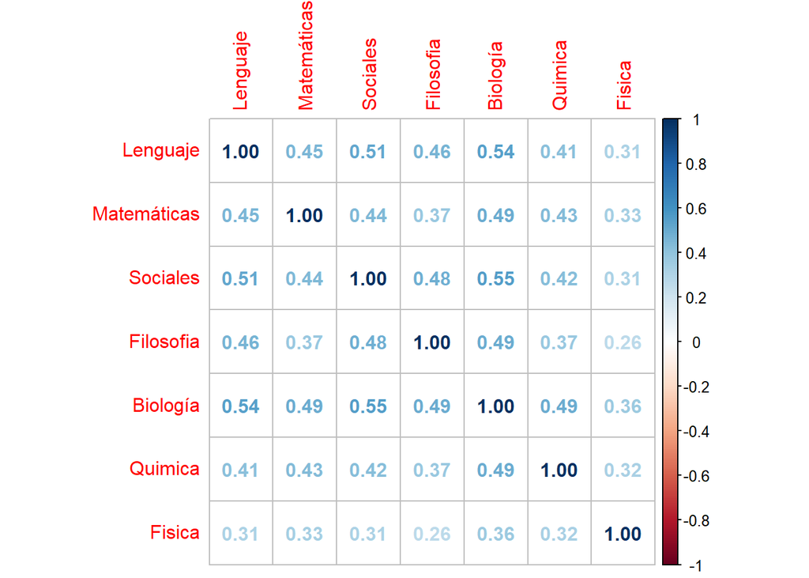

```r
library(corrplot)
corrplot(round(cor(M_Cor),2), method="number")
```

- P21: Construir un dispersograma entre los puntajes de (`LENGUAJE_PUNT`, `MATEMATICAS_PUNT`, `CIENCIAS_SOCIALES_PUNT`, `FILOSOFIA_PUNT`, `BIOLOGIA_PUNT`, `QUIMICA_PUNT`, `FISICA_PUNT`).

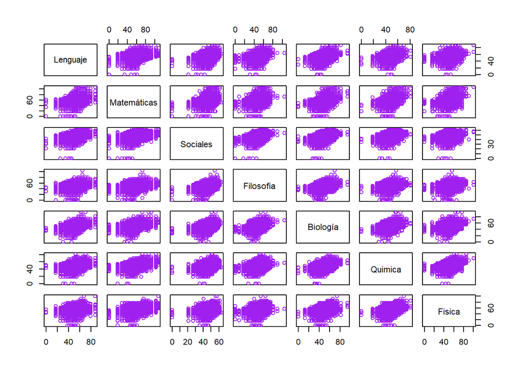

```r
pairs(M_Cor, col = "purple")
```

… otra alternativa de código

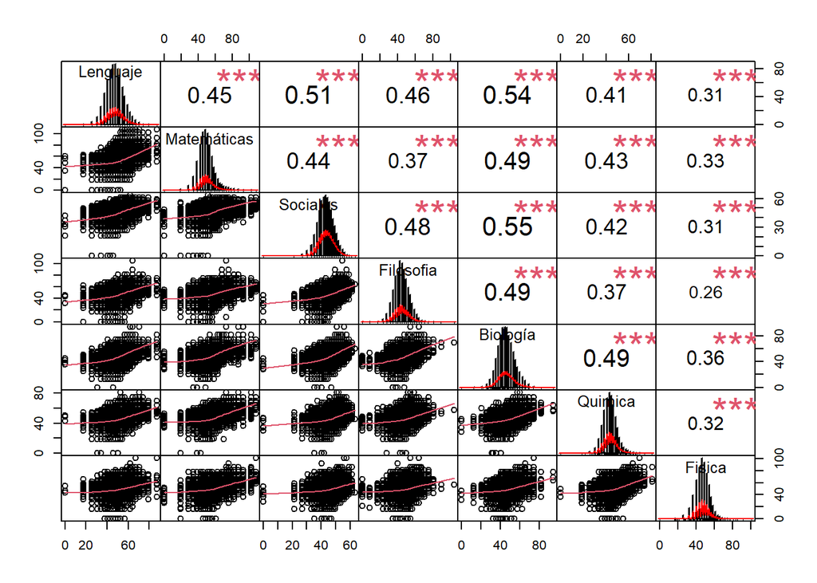

```r
library("PerformanceAnalytics")
chart.Correlation(M_Cor, method = "pearson", histogram = T)
```